# Multiple Linear Regression Example

# Problem Statement

Mileage of used cars is often thought of as a good predictor of sale prices of used cars. Does this same conjecture hold for so called “luxury cars”: Porsches, Jaguars, and BMWs? More precisely, do the slopes and intercepts differ when comparing mileage and price for these three brands of cars? To answer this question, data was randomly selected from an Internet car sale site. (Tweaked a bit from Cannon et al. 2013 [Chapter 1 and Chapter 4])

# Competing Hypotheses

There are many hypothesis tests to run here. It’s important to first think about the model that we will fit to address these questions. We want to predict `Price` (in thousands of dollars) based on `Mileage` (in thousands of miles). A simple linear regression equation for this would be $\hat{Price} = b_0 + b_1 * Mileage$.

We are dealing with a more complicated example in this case though. We need to also include `CarType` in our model. Since `CarType` has three levels: `BMW`, `Porsche`, and `Jaguar`, we encode this as two dummy variables with `BMW` as the baseline. To also allow the slopes to differ by car type, we incorporate *interaction* terms between `Mileage` and the `CarType` dummy variables:

$$\hat{Price} = b_0 + b_1 * Mileage + b_2
* Porsche + b_3 * Jaguar + b_4 \, Mileage*Jaguar + b_5 \,
Mileage*Porsche.$$

## In words

- Null hypothesis: The coefficients on the parameters (including interaction terms) of the least squares regression modeling price as a function of mileage and car type are zero.
- Alternative hypothesis: At least one of the coefficients on the parameters (including interaction terms) of the least squares regression modeling price as a function of mileage and car type are nonzero.

## In symbols (with annotations)

- $H_0: \beta_i = 0$, where $\beta_i$ represents the population coefficient of the least squares regression modeling price as a function of mileage and car type.
- $H_A:$ At least one $\beta_i \ne 0$

## Set $\alpha$

It’s important to set the significance level before starting the testing using the data. Let’s set the significance level at 5% here.

# Exploring the sample data

```r
data(ThreeCars)
three_cars <- ThreeCars |>
  select(CarType, Price, Mileage) |>
  mutate(CarType = as.character(CarType))
```

The scatterplot below shows the relationship between mileage, price, and car type, with separate least squares lines added.

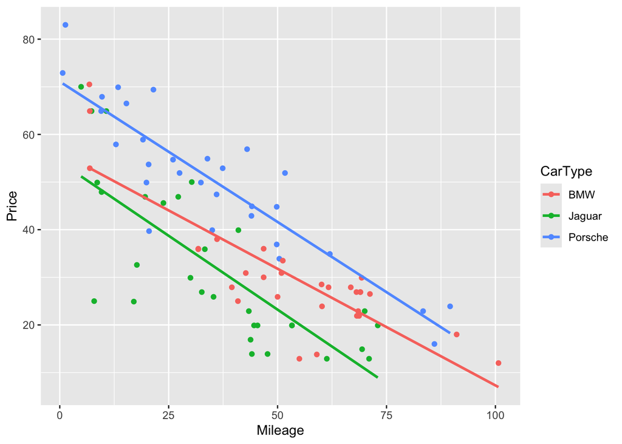

```r
three_cars |> ggplot(aes(x = Mileage, y = Price, color = CarType)) +
  geom_point() +
  geom_smooth(method = "lm", se = FALSE)
```

## Guess about statistical significance

# Non-traditional methods

We’ll use **`infer`**’s `fit()` function, which fits the regression model within the `infer` grammar. Permuting the response and refitting many times gives a null distribution for **each** coefficient.

## Observed coefficients

```r
obs_fit <- three_cars |>
  specify(Price ~ Mileage + CarType + Mileage:CarType) |>
  fit()
obs_fit
```

```
## # A tibble: 6 × 2
##   term                   estimate
##   <chr>                     <dbl>
## 1 intercept               56.3
## 2 Mileage                 -0.490
## 3 CarTypeJaguar           -2.06
## 4 CarTypePorsche          14.8
## 5 Mileage:CarTypeJaguar   -0.130
## 6 Mileage:CarTypePorsche  -0.0995
```

## Randomization for Hypothesis Test

Under the null of no association, the `Price` values are exchangeable, so `infer` shuffles the response with `hypothesize(null = "independence")`, refits the model, and records each coefficient 1,000 times.

```r
set.seed(2018)
null_fits <- three_cars |>
  specify(Price ~ Mileage + CarType + Mileage:CarType) |>
  hypothesize(null = "independence") |>
  generate(reps = 1000, type = "permute") |>
  fit()
```

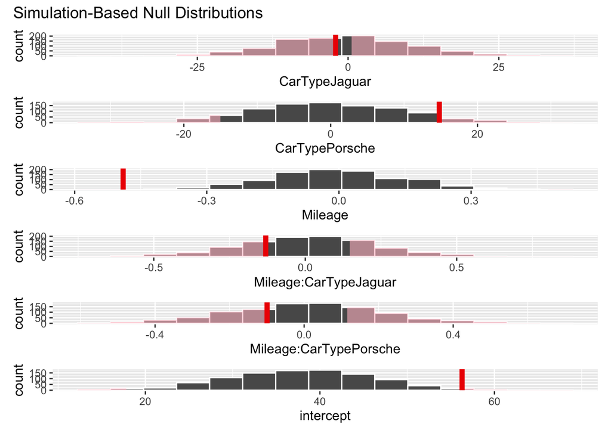

```r
visualize(null_fits) +
  shade_p_value(obs_stat = obs_fit, direction = "both")
```

### Calculate $p$-values

```r
get_p_value(null_fits, obs_stat = obs_fit, direction = "both")
```

```
## # A tibble: 6 × 2
##   term                   p_value
##   <chr>                    <dbl>
## 1 CarTypeJaguar            0.89
## 2 CarTypePorsche           0.122
## 3 Mileage                  0.002
## 4 Mileage:CarTypeJaguar    0.518
## 5 Mileage:CarTypePorsche   0.578
## 6 intercept                0.022
```

# Traditional methods

## Check conditions

Remember that in order to use the shortcut (formula-based, theoretical) approach, we need to check that some conditions are met. We fit the model and obtain fitted values and residuals with `moderndive`’s `get_regression_points()`.

```r
car_mult_lm <- lm(Price ~ Mileage * CarType, data = three_cars)
car_points <- get_regression_points(car_mult_lm)
```

1. *Linear relationship between response and predictors*: Look at the residual plot to see if the residuals are randomly distributed.

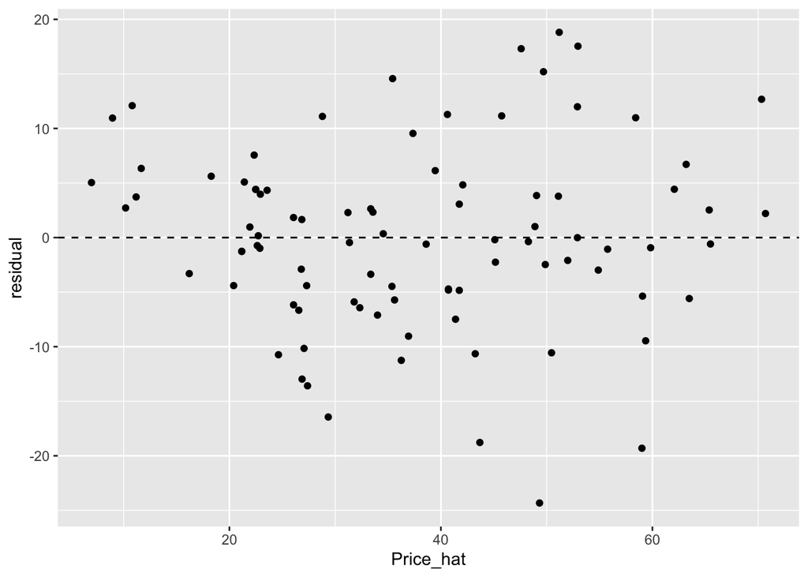

   ```r
   car_points |> ggplot(aes(x = Price_hat, y = residual)) +
     geom_point() +
     geom_hline(yintercept = 0, linetype = "dashed")
   ```

   There does not appear to be any strong pattern in the residuals so this condition is reasonably met.
2. *Independent observations and errors*: The cars were selected at random here so the independent observations condition is met.
3. *Nearly normal residuals*: Check a Q-Q plot on the residuals.

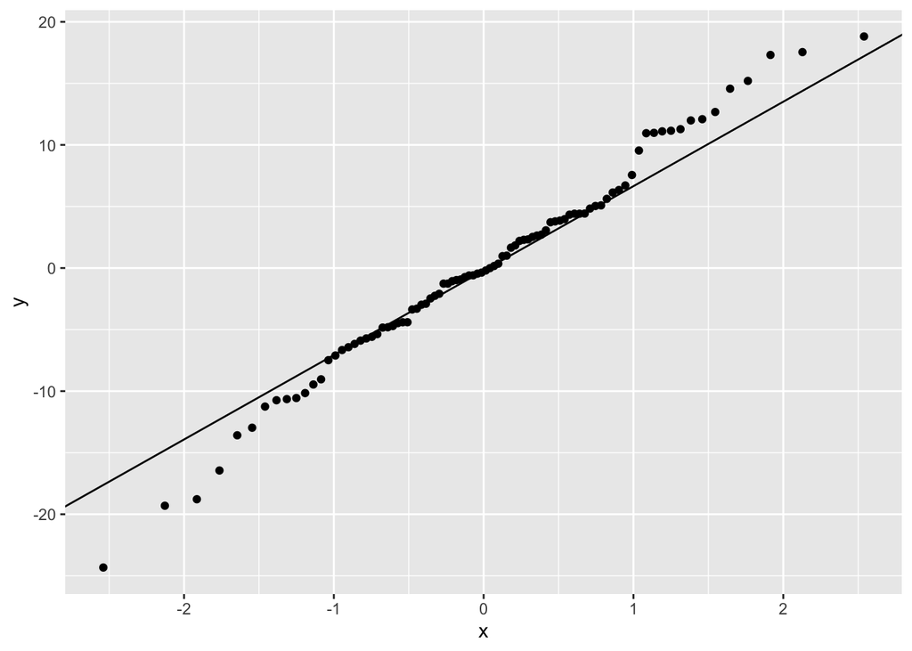

   ```r
   car_points |> ggplot(aes(sample = residual)) +
     stat_qq() + stat_qq_line()
   ```

   There are some small deviations from normality but this is a pretty good fit for normality of residuals.
4. *Equal variances across explanatory variable*: The residual plot does show a bit of a fan-shaped pattern from left to right, but it is not drastic.

## Test statistic

We estimate each population coefficient $\beta_i$ with the sample coefficient $B_i$, a random variable that varies from sample to sample. If the conditions are met and assuming $H_0$ is true, we can standardize each $B_i$ into a $T$ statistic that follows a $t$ distribution:

$$T =\dfrac{ B_i - 0}{ {SE}_i } \sim t
(df = n - k)$$

## Observed test statistic

We use the `lm` function to fit the model and conduct the theory-based test, summarizing the output with `moderndive`’s `get_regression_table()`.

```r
get_regression_table(car_mult_lm)
```

```
## # A tibble: 6 × 7
##   term                    estimate std_error statistic p_value lower_ci upper_ci
##   <chr>                      <dbl>     <dbl>     <dbl>   <dbl>    <dbl>    <dbl>
## 1 intercept                  56.3      4.16     13.5     0       48.0     64.6
## 2 Mileage                    -0.49     0.072    -6.78    0       -0.634   -0.346
## 3 CarType-Jaguar             -2.06     5.24     -0.394   0.695  -12.5      8.35
## 4 CarType-Porsche            14.8      5.04      2.94    0.004    4.78    24.8
## 5 Mileage:CarType-Jaguar     -0.13     0.106    -1.23    0.221   -0.341    0.08
## 6 Mileage:CarType-Porsche    -0.1      0.099    -1.00    0.32    -0.297    0.098
```

A couple of interpretations of the coefficients:

> For every one thousand mile increase in `Mileage` for a BMW car (holding all else fixed), we expect `Price` to decrease by about 0.49 thousands of dollars ($490).

> We predict Porsches to cost about $14,800 more than BMWs (holding mileage and interaction terms fixed).

# Compute $p$-values

# State conclusion

# Comparing results

Cannon, Ann R., George W. Cobb, Bradley A. Hartlaub, et al. 2013. *STAT2 - Building Models for a World of Data*.